# Predicting Scoring Ability

[figure not shown]

###### Taken from https://www.nba.com/news/nba-schedule-2018-19-revealed-official-release

## Introduction

### Author: James Zhang

The NBA, or National Basketball Association, has had millions of fans all over the world watching throughout the years. As someone who has been watching basketball since I was a young child, I’ve noticed that the game of basketball has changed over the past couple decades. More recently, the 3 point aspect of basketball has impacted the game more than ever, with popular superstars, such as Stephen Curry, although in small size, dominating the league. A popular idea associated with basketball is that only sizable, built, and powerful players can dominate the league, let alone play in the league. Something to consider also, is that there are 7.6 billion people on earth, yet only around 500 play in the NBA at a given time, making the current player's within the league that much more impressive. When you take a look at some of the greats, such as Shaquille O’Neal, Yao-Ming, and Wilt Chamberlain, it’s apparent that their shooting ability was far from exceptional. In fact, some of these greats have worse shooting percentages than college athletes! This completely contradicts the popular idea presented earlier, which was correlating scoring ability with one’s physical build. With this inspiration in mind, I wish to see if a specific height or if any other physical characteristic makes one a great shooter and if it’s possible to predict one’s shooting ability purely from a physical characteristics and statistics standpoint. Let’s take a deeper look into what makes a high scoring NBA player perform so well and then later on, attempt to make a model to predict how well one can perform, shooting wise, within the NBA.

```python
# Importing multiple libraries that contain useful functionalities! Using these for the tutorial!
import pandas as pd
import numpy as np
import seaborn as sns
import matplotlib.pyplot as plt
from sklearn.linear_model import LinearRegression
import statsmodels.formula.api as smf
from statsmodels.formula.api import ols
from sklearn import linear_model
from scipy.stats import ttest_ind
from sklearn.metrics import mean_squared_error


# pd.set_option('display.max_columns', None)
# pd.set_option('display.max_rows', None)
pd.reset_option('^display.', silent=True)
```

Within this tutorial, we will be using mulitple online libraries with very useful functionalities! If you would like to learn more about a specific library, please click on the corresponding one! [Pandas](https://pandas.pydata.org/pandas-docs/stable/)  
[Numpy](https://numpy.org/doc/stable/user/)  
[Matplotlib](https://matplotlib.org/stable/users/index.html)  
[Scikit-learn](https://scikit-learn.org/stable/index.html)  
[Seaborn](https://seaborn.pydata.org/) You can find the datasets below!  
[Datasets](https://www.kaggle.com/drgilermo/nba-players-stats)

## Data Collection and Cleaning

For this tutorial, we will be using some datasets found on Kaggle. The first dataset, 'Players.csv', contains information about a NBA players' physical characteristics and where they are from. The second dataset, 'Seasons_Stats.csv', contains NBA players' performance statistics. Each of these datasets, should be downloaded into your repository, if you want to conduct an analysis through code, like this tutorial. Please note that these datasets are formatted as CSV files, or Comma Seperates Value files. There are functionalities within pandas, which make it easy to translate this information into a dataframe.  
Now, let's actually translate the CSVs into dataframes that we can modify and use to analyze!

```python
players = pd.read_csv('Players.csv')
players.head()
```

|  | Unnamed: 0 | Player | height | weight | collage | born | birth_city | birth_state |
| --- | --- | --- | --- | --- | --- | --- | --- | --- |
| 0 | 0 | Curly Armstrong | 180.0 | 77.0 | Indiana University | 1918.0 | NaN | NaN |
| 1 | 1 | Cliff Barker | 188.0 | 83.0 | University of Kentucky | 1921.0 | Yorktown | Indiana |
| 2 | 2 | Leo Barnhorst | 193.0 | 86.0 | University of Notre Dame | 1924.0 | NaN | NaN |
| 3 | 3 | Ed Bartels | 196.0 | 88.0 | North Carolina State University | 1925.0 | NaN | NaN |
| 4 | 4 | Ralph Beard | 178.0 | 79.0 | University of Kentucky | 1927.0 | Hardinsburg | Kentucky |

In the above players dataset, we see that there are 8 columns. For the most part, they are self-explanatory. Note that some columns have NaN within them. This means that the dataset wasn't able to capture this information for a specific player.

- Unnamed- Id of each row
- Name of the Player
- Physical Characteristics (Weight [KG], Height [CM])
- Birth Information (Year, City, State)
- College Attended

```python
seasons_stats = pd.read_csv('Seasons_Stats.csv')
seasons_stats.head()
```

|  | Unnamed: 0 | Year | Player | Pos | Age | Tm | G | GS | MP | PER | ... | FT% | ORB | DRB | TRB | AST | STL | BLK | TOV | PF | PTS |
| --- | --- | --- | --- | --- | --- | --- | --- | --- | --- | --- | --- | --- | --- | --- | --- | --- | --- | --- | --- | --- | --- |
| 0 | 0 | 1950.0 | Curly Armstrong | G-F | 31.0 | FTW | 63.0 | NaN | NaN | NaN | ... | 0.705 | NaN | NaN | NaN | 176.0 | NaN | NaN | NaN | 217.0 | 458.0 |
| 1 | 1 | 1950.0 | Cliff Barker | SG | 29.0 | INO | 49.0 | NaN | NaN | NaN | ... | 0.708 | NaN | NaN | NaN | 109.0 | NaN | NaN | NaN | 99.0 | 279.0 |
| 2 | 2 | 1950.0 | Leo Barnhorst | SF | 25.0 | CHS | 67.0 | NaN | NaN | NaN | ... | 0.698 | NaN | NaN | NaN | 140.0 | NaN | NaN | NaN | 192.0 | 438.0 |
| 3 | 3 | 1950.0 | Ed Bartels | F | 24.0 | TOT | 15.0 | NaN | NaN | NaN | ... | 0.559 | NaN | NaN | NaN | 20.0 | NaN | NaN | NaN | 29.0 | 63.0 |
| 4 | 4 | 1950.0 | Ed Bartels | F | 24.0 | DNN | 13.0 | NaN | NaN | NaN | ... | 0.548 | NaN | NaN | NaN | 20.0 | NaN | NaN | NaN | 27.0 | 59.0 |

5 rows × 53 columns

In the above players dataset, there are 50 plus columns. For the most part, they are self-explanatory. Note that some columns have NaN within them. This means that the dataset wasn't able to capture this information for a specific player or some of this information wasn't required to be captured at the time. For example, the 3 point line was introduced later on into the game! Some of the columns in this dataset are the following.

- Player's Info (Name, Age, Year in the NBA)
- Position
- Statistics (Free Throw, 3 Point, 2 Point, Field Goal, Steals, etc.)

For the sake of the project, we will only be looking at a subset of these columns instead of all of them!

```python
player_data = pd.read_csv('player_data.csv')
player_data.rename(columns={'name':'Player'}, inplace=True)
player_data.head()
```

|  | Player | year_start | year_end | position | height | weight | birth_date | college |
| --- | --- | --- | --- | --- | --- | --- | --- | --- |
| 0 | Alaa Abdelnaby | 1991 | 1995 | F-C | 6-10 | 240.0 | June 24, 1968 | Duke University |
| 1 | Zaid Abdul-Aziz | 1969 | 1978 | C-F | 6-9 | 235.0 | April 7, 1946 | Iowa State University |
| 2 | Kareem Abdul-Jabbar | 1970 | 1989 | C | 7-2 | 225.0 | April 16, 1947 | University of California, Los Angeles |
| 3 | Mahmoud Abdul-Rauf | 1991 | 2001 | G | 6-1 | 162.0 | March 9, 1969 | Louisiana State University |
| 4 | Tariq Abdul-Wahad | 1998 | 2003 | F | 6-6 | 223.0 | November 3, 1974 | San Jose State University |

```python
players.rename(columns={'height': 'height_cm', 'weight': 'weight_kg', 'collage': 'college'}, inplace=True)
players.head()
```

|  | Unnamed: 0 | Player | height_cm | weight_kg | college | born | birth_city | birth_state |
| --- | --- | --- | --- | --- | --- | --- | --- | --- |
| 0 | 0 | Curly Armstrong | 180.0 | 77.0 | Indiana University | 1918.0 | NaN | NaN |
| 1 | 1 | Cliff Barker | 188.0 | 83.0 | University of Kentucky | 1921.0 | Yorktown | Indiana |
| 2 | 2 | Leo Barnhorst | 193.0 | 86.0 | University of Notre Dame | 1924.0 | NaN | NaN |
| 3 | 3 | Ed Bartels | 196.0 | 88.0 | North Carolina State University | 1925.0 | NaN | NaN |
| 4 | 4 | Ralph Beard | 178.0 | 79.0 | University of Kentucky | 1927.0 | Hardinsburg | Kentucky |

## Exploratory Data Analysis

```python
tallestPlayerRow = players.iloc[players['height_cm'].idxmax()]
print('Tallest player in the NBA was ' + tallestPlayerRow['Player'] + ' with a height of ' + str(tallestPlayerRow['height_cm']) + ' cm.')

shortestPlayerRow = players.iloc[players['height_cm'].idxmin()]
print('Shortest player in the NBA was ' + shortestPlayerRow['Player'] + ' with a height of ' + str(shortestPlayerRow['height_cm']) + ' cm.')
```

```
Tallest player in the NBA was Manute Bol with a height of 231.0 cm.
Shortest player in the NBA was Muggsy Bogues with a height of 160.0 cm.
```

```python
heaviestPlayerRow = players.iloc[players['weight_kg'].idxmax()]
print('Heaviest player in the NBA was ' + heaviestPlayerRow['Player'] + ' with a weight of ' + str(heaviestPlayerRow['weight_kg']) + ' kg.')

lightestPlayerRow = players.iloc[players['weight_kg'].idxmin()]
print('Lightest player in the NBA was ' + lightestPlayerRow['Player'] + ' with a weight of ' + str(lightestPlayerRow['weight_kg']) + ' kg.')
```

```
Heaviest player in the NBA was Sim Bhullar with a weight of 163.0 kg.
Lightest player in the NBA was Spud Webb with a weight of 60.0 kg.
```

With this, we see that the range for the height is between 160cm to 231cm. Also, we see that the range for weiht is between 60kg to 163kg.

```
[]
```

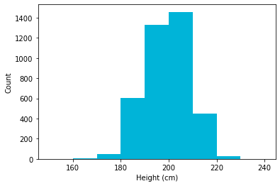

```python
bins=range(150, 250, 10) #Range of Intervals, width size of each bar
plt.hist(players["height_cm"],bins,histtype="bar",color='#00b4d8')
plt.xlabel('Height (cm)')
plt.ylabel('Count')
plt.plot()
```

From the graph, we see that the majority of the players within the NBA, are around the 190cm - 210cm height range.

```
[]
```

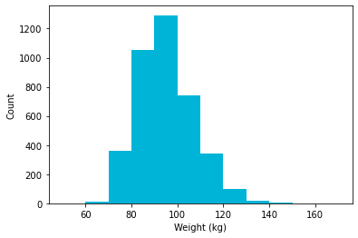

```python
bins=range(50, 175, 10) #Range of Intervals, width size of each bar
plt.hist(players["weight_kg"],bins,histtype="bar",color='#00b4d8')
plt.xlabel('Weight (kg)')
plt.ylabel('Count')
plt.plot()
```

With this graph, we can see the distribution of weight in the NBA. It seems that most NBA players are within the 80kg to 110kg range, with a few outside of this range.

```python
array = players['college'].value_counts()
print(array)

print('-------------------')

array = players['birth_state'].value_counts()
print(array)
```

```
University of Kentucky                   89
University of California, Los Angeles    86
University of North Carolina             67
University of Kansas                     59
Duke University                          56
                                         ..
Fayetteville State University             1
Fort Valley State University              1
Pfeiffer University                       1
City College of San Francisco             1
University of Maine                       1
Name: college, Length: 422, dtype: int64
-------------------
California               344
New York                 290
Illinois                 209
Pennsylvania             163
Ohio                     137
                        ...
South Africa               1
Alaska                     1
Slovakia                   1
Trinidad and Tobago        1
Republic of the Congo      1
Name: birth_state, Length: 128, dtype: int64
```

Something cool to notice is that the University of Kentucky was produced the most players in NBA History! In addition, the state most NBA players are from are California and New York, respectively.

```python
combined = pd.merge(players, seasons_stats, on='Player')
combined = pd.merge(combined,player_data, on='Player')
combined.drop(columns=['Unnamed: 0_x', 'Unnamed: 0_y'], inplace=True) #Dropping unneeded columns

combined['FG%'].fillna(combined['FG%'].mean(), inplace=True)
combined['FT%'].fillna(combined['FT%'].mean(), inplace=True)

combined.head()
```

|  | Player | height_cm | weight_kg | college_x | born | birth_city | birth_state | Year | Pos | Age | ... | TOV | PF | PTS | year_start | year_end | position | height | weight | birth_date | college_y |
| --- | --- | --- | --- | --- | --- | --- | --- | --- | --- | --- | --- | --- | --- | --- | --- | --- | --- | --- | --- | --- | --- |
| 0 | Curly Armstrong | 180.0 | 77.0 | Indiana University | 1918.0 | NaN | NaN | 1950.0 | G-F | 31.0 | ... | NaN | 217.0 | 458.0 | 1949 | 1951 | G-F | 5-11 | 170.0 | November 1, 1918 | Indiana University |
| 1 | Curly Armstrong | 180.0 | 77.0 | Indiana University | 1918.0 | NaN | NaN | 1951.0 | G-F | 32.0 | ... | NaN | 97.0 | 202.0 | 1949 | 1951 | G-F | 5-11 | 170.0 | November 1, 1918 | Indiana University |
| 2 | Cliff Barker | 188.0 | 83.0 | University of Kentucky | 1921.0 | Yorktown | Indiana | 1950.0 | SG | 29.0 | ... | NaN | 99.0 | 279.0 | 1950 | 1952 | G | 6-2 | 185.0 | January 15, 1921 | University of Kentucky |
| 3 | Cliff Barker | 188.0 | 83.0 | University of Kentucky | 1921.0 | Yorktown | Indiana | 1951.0 | SG | 30.0 | ... | NaN | 98.0 | 152.0 | 1950 | 1952 | G | 6-2 | 185.0 | January 15, 1921 | University of Kentucky |
| 4 | Cliff Barker | 188.0 | 83.0 | University of Kentucky | 1921.0 | Yorktown | Indiana | 1952.0 | SG | 31.0 | ... | NaN | 56.0 | 126.0 | 1950 | 1952 | G | 6-2 | 185.0 | January 15, 1921 | University of Kentucky |

5 rows × 65 columns

Something we need to take of is the fact that some of FG% and FT% are NaN. This is because the player never had a chance to shoot that kind of shot. Because of this, we will replace those values with the mean of the column to avoid any errors later on. In addition to this, some FG% and FT% are 1, meaning they never missed. That's likely due to the fact that they took a low number of shots. I will not be modifying this, but this is likely going to affect our results later on.

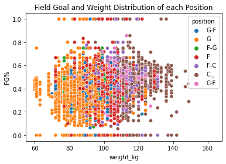

```python
sns.scatterplot(data=combined, x="weight_kg", y="FG%", hue='position')
plt.title('Field Goal and Weight Distribution of each Position')
plt.show()
```

Notice that some positions are duplicated. G-F, or Guard-Forward, is the same as F-G. The same can be said about F-C and C-F. Because of this, we will need to fix this in our graph. In addition, the graph is a bit hard to distinguish between all positions. Because of this, we will make a graph for each position instead!

```python
for index, row in combined.iterrows():
    currentPosition = row['position']

    if (currentPosition == 'G-F'):
        combined.at[index, 'position'] = 'F-G'
    elif (currentPosition == 'F-C'):
        combined.at[index, 'position'] = 'C-F'

combined.position.unique()
```

```
array(['F-G', 'G', 'F', 'C-F', 'C', nan], dtype=object)
```

We have now fixed the duplicates in the positions, now let's create a graph for each position. Let's look at the FG% and FT% compared to the weight and then height, for each position!

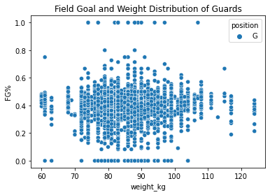

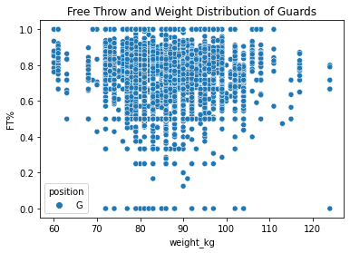

```python
sns.scatterplot(data=combined.loc[combined['position'] == 'G'], x="weight_kg", y="FG%", hue='position')
plt.title('Field Goal and Weight Distribution of Guards')
plt.show()

sns.scatterplot(data=combined.loc[combined['position'] == 'G'], x="weight_kg", y="FT%", hue='position')
plt.title('Free Throw and Weight Distribution of Guards')
plt.show()
```

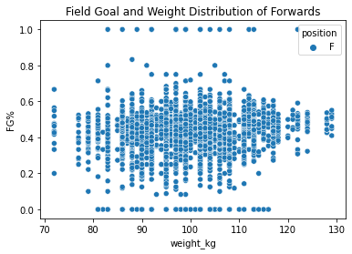

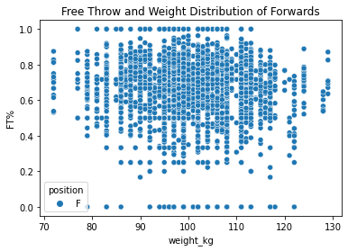

```python
sns.scatterplot(data=combined.loc[combined['position'] == 'F'], x="weight_kg", y="FG%", hue='position')
plt.title('Field Goal and Weight Distribution of Forwards')
plt.show()

sns.scatterplot(data=combined.loc[combined['position'] == 'F'], x="weight_kg", y="FT%", hue='position')
plt.title('Free Throw and Weight Distribution of Forwards')
plt.show()
```

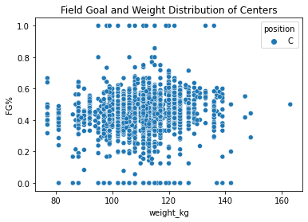

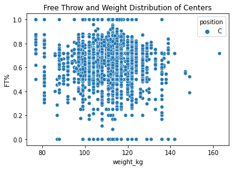

```python
sns.scatterplot(data=combined.loc[combined['position'] == 'C'], x="weight_kg", y="FG%", hue='position')
plt.title('Field Goal and Weight Distribution of Centers')
plt.show()

sns.scatterplot(data=combined.loc[combined['position'] == 'C'], x="weight_kg", y="FT%", hue='position')
plt.title('Free Throw and Weight Distribution of Centers')
plt.show()
```

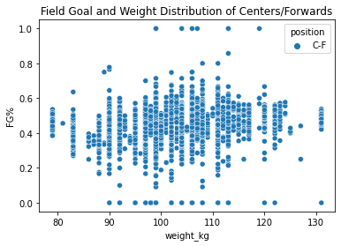

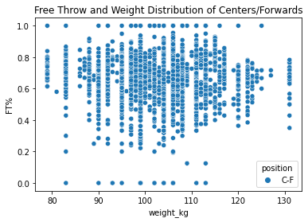

```python
sns.scatterplot(data=combined.loc[combined['position'] == 'C-F'], x="weight_kg", y="FG%", hue='position')
plt.title('Field Goal and Weight Distribution of Centers/Forwards')
plt.show()

sns.scatterplot(data=combined.loc[combined['position'] == 'C-F'], x="weight_kg", y="FT%", hue='position')
plt.title('Free Throw and Weight Distribution of Centers/Forwards')
plt.show()
```

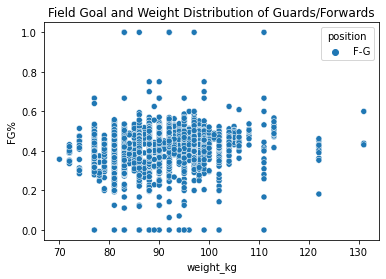

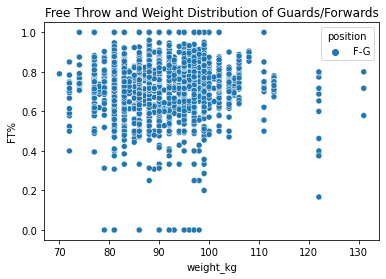

```python
sns.scatterplot(data=combined.loc[combined['position'] == 'F-G'], x="weight_kg", y="FG%", hue='position')
plt.title('Field Goal and Weight Distribution of Guards/Forwards')
plt.show()

sns.scatterplot(data=combined.loc[combined['position'] == 'F-G'], x="weight_kg", y="FT%", hue='position')
plt.title('Free Throw and Weight Distribution of Guards/Forwards')
plt.show()
```

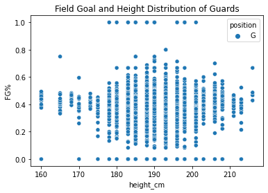

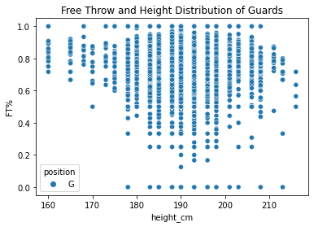

```python
sns.scatterplot(data=combined.loc[combined['position'] == 'G'], x="height_cm", y="FG%", hue='position')
plt.title('Field Goal and Height Distribution of Guards')
plt.show()

sns.scatterplot(data=combined.loc[combined['position'] == 'G'], x="height_cm", y="FT%", hue='position')
plt.title('Free Throw and Height Distribution of Guards')
plt.show()
```

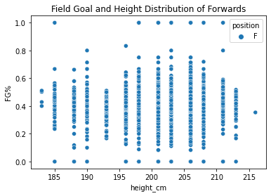

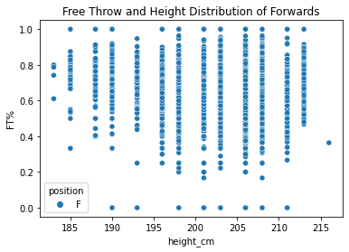

```python
sns.scatterplot(data=combined.loc[combined['position'] == 'F'], x="height_cm", y="FG%", hue='position')
plt.title('Field Goal and Height Distribution of Forwards')
plt.show()

sns.scatterplot(data=combined.loc[combined['position'] == 'F'], x="height_cm", y="FT%", hue='position')
plt.title('Free Throw and Height Distribution of Forwards')
plt.show()
```

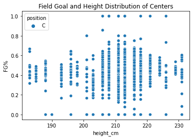

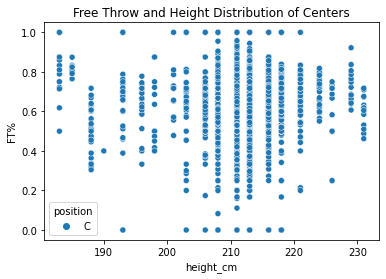

```python
sns.scatterplot(data=combined.loc[combined['position'] == 'C'], x="height_cm", y="FG%", hue='position')
plt.title('Field Goal and Height Distribution of Centers')
plt.show()

sns.scatterplot(data=combined.loc[combined['position'] == 'C'], x="height_cm", y="FT%", hue='position')
plt.title('Free Throw and Height Distribution of Centers')
plt.show()
```

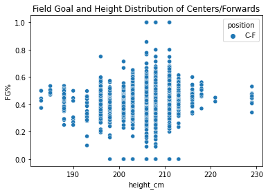

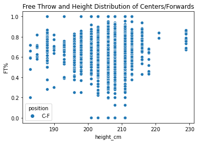

```python
sns.scatterplot(data=combined.loc[combined['position'] == 'C-F'], x="height_cm", y="FG%", hue='position')
plt.title('Field Goal and Height Distribution of Centers/Forwards')
plt.show()

sns.scatterplot(data=combined.loc[combined['position'] == 'C-F'], x="height_cm", y="FT%", hue='position')
plt.title('Free Throw and Height Distribution of Centers/Forwards')
plt.show()
```

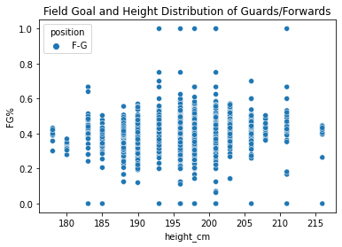

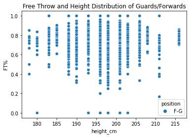

```python
sns.scatterplot(data=combined.loc[combined['position'] == 'F-G'], x="height_cm", y="FG%", hue='position')
plt.title('Field Goal and Height Distribution of Guards/Forwards')
plt.show()

sns.scatterplot(data=combined.loc[combined['position'] == 'F-G'], x="height_cm", y="FT%", hue='position')
plt.title('Free Throw and Height Distribution of Guards/Forwards')
plt.show()
```

Oddly enough, it appears that if someone is a one end of the spectrum, meaning on the shorter side or taller side, than average for that position, their shooting percentage appears to be higher and more consistent. The spread is much lower on those ends. However, something to note is that there are a lot fewer NBA players on those ends which makes it unsafe to state this observation as a fact.

## Predicting Shooting Ability from Physical Characteristics

```python
from sklearn.model_selection import train_test_split
from sklearn.metrics import r2_score

x = combined[['height_cm','weight_kg', 'FTA', 'FGA']]
y = combined['FG%']

x_train, x_test, y_train, y_test = train_test_split(x, y, test_size = 0.2, random_state = 42)

LR = LinearRegression()
LR.fit(x_train,y_train)

y_prediction = LR.predict(x_test)
y_prediction

score=r2_score(y_test,y_prediction)
print('r-squared score is ',score)
```

```
r-squared score is  0.10489551041274636
```

```python
from sklearn.model_selection import train_test_split
from sklearn.metrics import r2_score

x = combined[['height_cm','weight_kg', 'FTA', 'FGA']]
y = combined['FT%']

x_train, x_test, y_train, y_test = train_test_split(x, y, test_size = 0.2, random_state = 42)

LR = LinearRegression()
LR.fit(x_train,y_train)

y_prediction = LR.predict(x_test)
y_prediction

score=r2_score(y_test,y_prediction)
print('r-squared score is ',score)
```

```
r-squared score is  0.13828338057457257
```

This r-squared score is fairly low. This is likely due to the fact that there were a couple outliers. More specifcially, there were some players with 100% shooting accuracy or 0%. These players likely didn't take many shots. Despite putting into our model, the number of free throw attempts and field goal attempts, this still resulted in a low r-squared values.

## Conclusions

The NBA is one of the most competitive sport leagues. This is where the best of the best play, and there a bunch of factors and skills that determine one's competence in the league.

Although we hypothesized that physical characteristics like height and weight may play a role to an NBA's player's shooting ability, it's clear that we are unable to figure out a prediction model and that further analysis is needed. It's likely due to the fact that there are so many other things at play, such as the mental strength, confidence of a player, and injuries side of a player, that make it hard to simply predict one's ability. We see, so many times, there be "busts" in the drafts. Those who performed well in high school/college, but their performance didn't transfer to the NBA.

I hope this tutorial made sense and that you enjoyed despite us not finding a "definitive" answer.